# Series de tiempo

Luis Apáez

28/03/2022

## Ejemplo práctico (parte II)

Retomamos los diferentes modelos que vimos al final de la clase pasada

```r
# Modelo hallado
fit1 <- arima(log(AirPassengers), c(0,1,1), seasonal = list(order = c(0,1,1), period = 12))

# Alternativas
fit2 <- arima(log(AirPassengers), c(0,1,1), seasonal = list(order = c(2,1,2), period = 12))
fit3 <- arima(log(AirPassengers), c(2,1,1), seasonal = list(order = c(0,1,0), period = 12))
```

Lo que debería seguir a continuación es la verificación de los supuestos para cada uno de los modelos restantes (`fit2` y `fit3`), no obstante, daremos por hecho que los supuestos son cumplidos por éstos.

### Volatilidad

Consideremos la siguiente serie de tiempo sobre los precios diarios del oro:

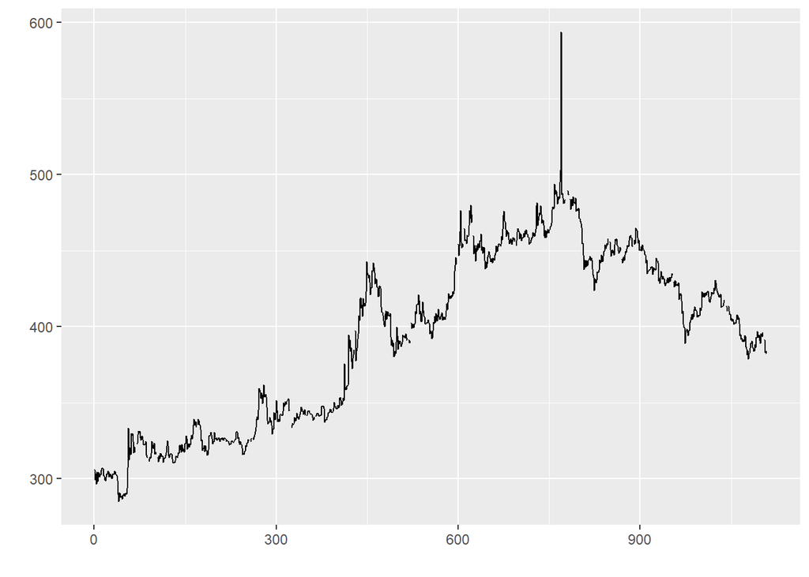

```r
data(gold)
autoplot(gold)
```

Notamos un comportamiento peculiar en esta serie de tiempo, pues podemos ver “picos” atípicos al comportamiento general. Lo anterior tiene una repercusión directa en la variabilidad de los datos y en general veremos que la modelación de tipo *ARIMA* no será la adecuada para series que presenten comportamientos de volatilidad.

Además, observemos que

```r
summary(gold)
```

```
##    Min. 1st Qu.  Median    Mean 3rd Qu.    Max.    NA's
##   285.0   337.7   403.2   392.5   443.7   593.7      34
```

en la serie hay 34 datos marcados como `NA's`, por lo cual realizamos una imputación

```r
# serie de tiempo sin los NA realizando la imputación na.mean()
Xt <- ts(na_mean(gold), frequency = 261, start = c(1985, 1))
```

Luego, como los supuestos no se cumplen o fallan debido a la volatilidad, podemos utilizar (en vez de la modelación *ARIMA*) el modelo de *Holt-Winterse* como sigue

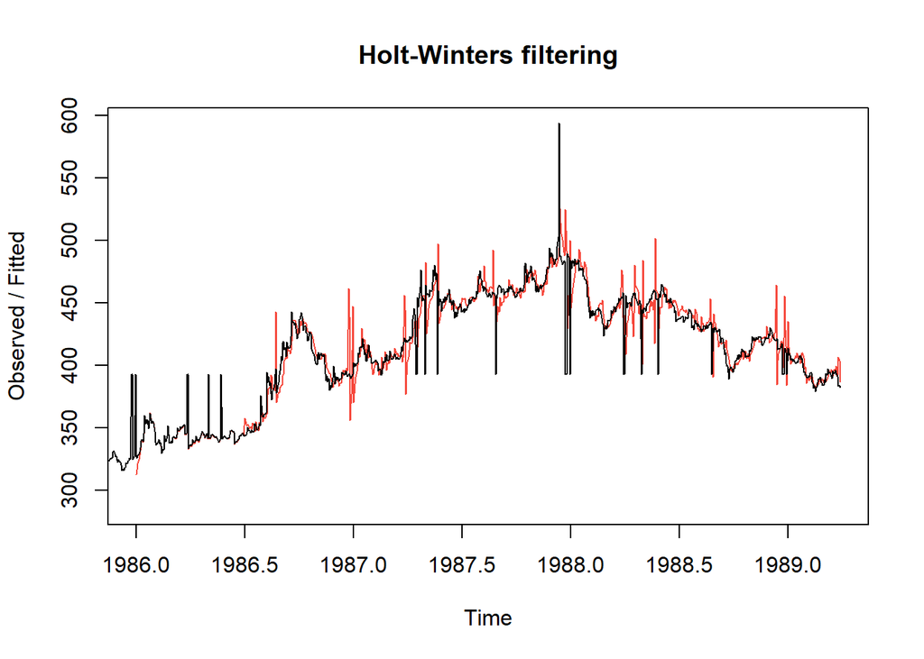

```r
# probamos con un modelo aditivo
HWmod <- HoltWinters(Xt, seasonal="additive")
plot(HWmod)
```

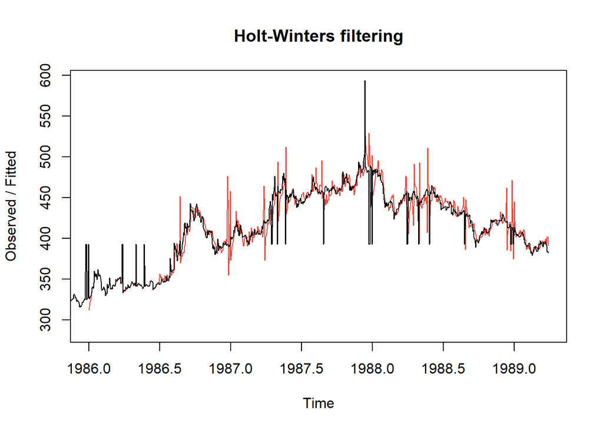

```r
# Probamos con un modelo multiplicativo
HWmod <- HoltWinters(Xt, seasonal="multiplicative")
plot(HWmod)
```

y no vemos grandes diferencias entre dichos modelos. Luego

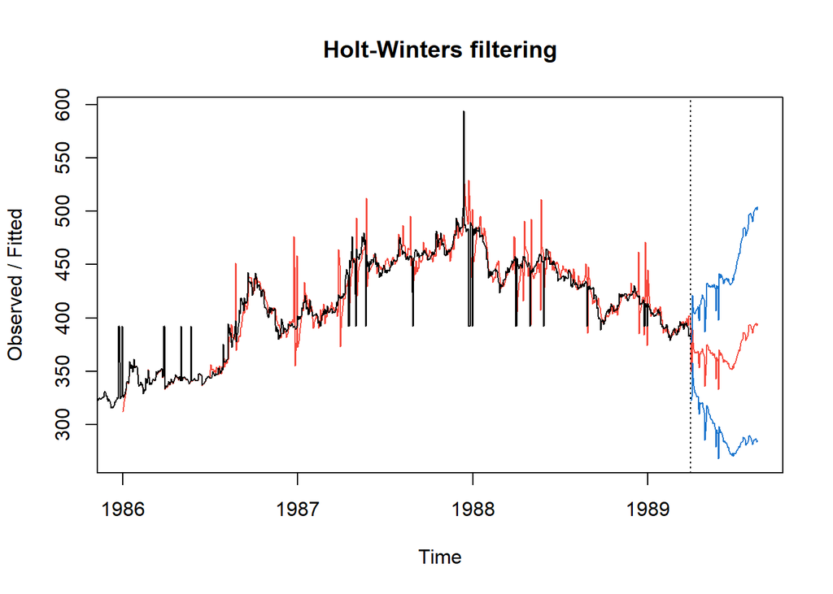

```r
# Realizamos la predicción
HWpred <- predict(HWmod, 100, prediction.interval = TRUE)
plot(HWmod, HWpred)
```

donde vemos intervalos de confianza muy amplios dada la variación en el tiempo, pero aún así logramos ver un patrón en la predicción basado en las observaciones previas.

Otra alternativa es utilizar el modelo *GARCH* (modelo autoregresivo generalizado condicional heterocedástico), en el cual la varianza futura depende de la varianza histórica y ésta depende de las observaciones. Este modelo se ocupa para predecir la volatilidad a mediano y corto plazo, además de capturar las agrupaciones de volatilidad.

Así, comenzamos por visualizar los log-rendimientos:

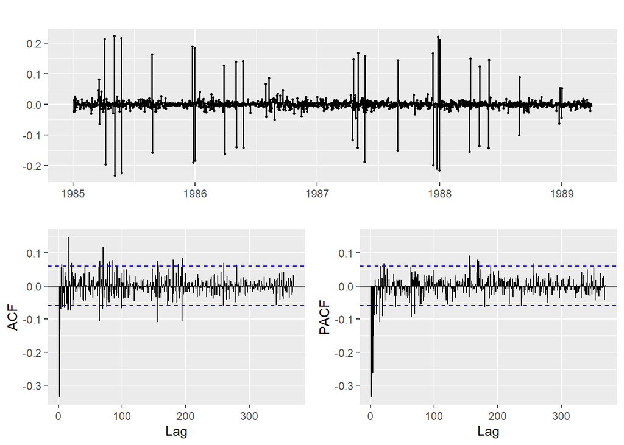

```r
# Log-rendimientos

rt = diff(log(Xt))
ggtsdisplay(rt)
```

en el cual vemos picos drásticos en comparación con el comportamiento general de la serie, es decir, podemos visualizar las volatilidades de los datos. Luego

```r
# Ajuste del modelo GARCH(1,1) sobre los log-rendimientos utilizando como
# distribución condicional una norma
Gmod <- garchFit(formula = ~ garch(1,1), data = rt, cond.dist="norm", trace=FALSE)
summary(Gmod)
```

```
##
## Title:
##  GARCH Modelling
##
## Call:
##  garchFit(formula = ~garch(1, 1), data = rt, cond.dist = "norm",
##     trace = FALSE)
##
## Mean and Variance Equation:
##  data ~ garch(1, 1)
## <environment: 0x0000000021c91c98>
##  [data = rt]
##
## Conditional Distribution:
##  norm
##
## Coefficient(s):
##         mu       omega      alpha1       beta1
## 2.8963e-04  7.6303e-05  1.4663e-01  8.0804e-01
##
## Std. Errors:
##  based on Hessian
##
## Error Analysis:
##         Estimate  Std. Error  t value Pr(>|t|)
## mu     2.896e-04   7.379e-04    0.393    0.695
## omega  7.630e-05   1.164e-05    6.553 5.64e-11 ***
## alpha1 1.466e-01   2.062e-02    7.113 1.14e-12 ***
## beta1  8.080e-01   1.919e-02   42.112  < 2e-16 ***
## ---
## Signif. codes:  0 '***' 0.001 '**' 0.01 '*' 0.05 '.' 0.1 ' ' 1
##
## Log Likelihood:
##  2393.303    normalized:  2.161972
##
## Description:
##  Mon Apr 04 17:04:58 2022 by user: weeee
##
##
## Standardised Residuals Tests:
##                                 Statistic p-Value
##  Jarque-Bera Test   R    Chi^2  49119.24  0
##  Shapiro-Wilk Test  R    W      0.5618694 0
##  Ljung-Box Test     R    Q(10)  59.91404  3.762606e-09
##  Ljung-Box Test     R    Q(15)  79.52255  8.538825e-11
##  Ljung-Box Test     R    Q(20)  90.2518   6.698042e-11
##  Ljung-Box Test     R^2  Q(10)  6.937937  0.7312908
##  Ljung-Box Test     R^2  Q(15)  15.66322  0.4047806
##  Ljung-Box Test     R^2  Q(20)  17.17775  0.6414033
##  LM Arch Test       R    TR^2   6.584141  0.8838287
##
## Information Criterion Statistics:
##       AIC       BIC       SIC      HQIC
## -4.316718 -4.298617 -4.316744 -4.309872
```

Y realizamos la predicción

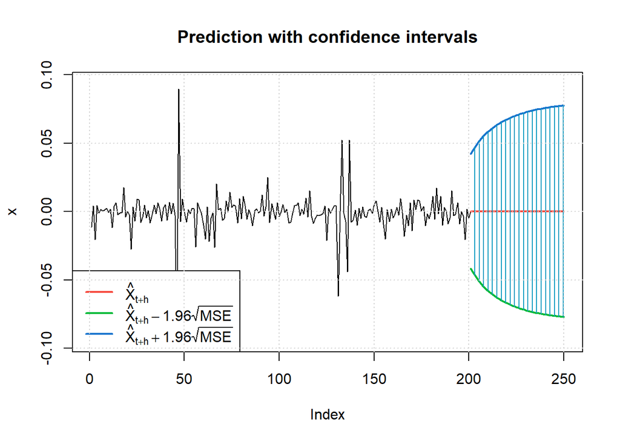

```
##    meanForecast  meanError standardDeviation lowerInterval upperInterval
## 1  0.0002896306 0.02144276        0.02144276   -0.04173741    0.04231667
## 2  0.0002896306 0.02269923        0.02269923   -0.04420005    0.04477931
## 3  0.0002896306 0.02383704        0.02383704   -0.04643010    0.04700937
## 4  0.0002896306 0.02487476        0.02487476   -0.04846400    0.04904326
## 5  0.0002896306 0.02582657        0.02582657   -0.05032952    0.05090878
## 6  0.0002896306 0.02670361        0.02670361   -0.05204848    0.05262774
## 7  0.0002896306 0.02751482        0.02751482   -0.05363843    0.05421769
## 8  0.0002896306 0.02826756        0.02826756   -0.05511376    0.05569302
## 9  0.0002896306 0.02896793        0.02896793   -0.05648646    0.05706572
## 10 0.0002896306 0.02962111        0.02962111   -0.05776667    0.05834593
## 11 0.0002896306 0.03023152        0.03023152   -0.05896306    0.05954232
## 12 0.0002896306 0.03080298        0.03080298   -0.06008310    0.06066236
## 13 0.0002896306 0.03133881        0.03133881   -0.06113332    0.06171258
## 14 0.0002896306 0.03184195        0.03184195   -0.06211945    0.06269871
```

[output cut: 36 more lines]

```r
predict(Gmod, n.ahead=50, plot=TRUE, nx=200)
```

donde vemos grandes intervalos de confianza pues el comportamiento de las volatilidades presentan valores grandes comparados con el resto de las observaciones.

### Modelos GARCH

Comenzamos por cargar los datos que contienen los precios diarios del petroleo

```r
datos <- read.csv("PrecioDiario2.csv", header=T, dec=",", sep=";")
head(datos,5)
```

```
##      Fecha Precio Dato
## 1 01/01/99   8.30    1
## 2 04/01/99   8.63    2
## 3 05/01/99   8.51    3
## 4 06/01/99   9.21    4
## 5 07/01/99   9.46    5
```

notamos que los precios son sólo de los días laborales, por lo cual nuestra serie de tiempo tendrá varios valores `NA`. Por ello imputamos como sigue

```r
attach(datos)
# gurdamos los valores de los precios en un vector
precio <- as.numeric(as.vector(Precio))

# vemos los valores faltantes
summary(precio)
```

```
##    Min. 1st Qu.  Median    Mean 3rd Qu.    Max.    NA's
##    7.81   25.75   49.10   55.48   85.51  132.71       5
```

Luego

```r
# imputar los valores faltantes con el metodo de ma
precio <- na_ma(precio, k = 4, weighting = "exponential")
```

Ahora, vemos que

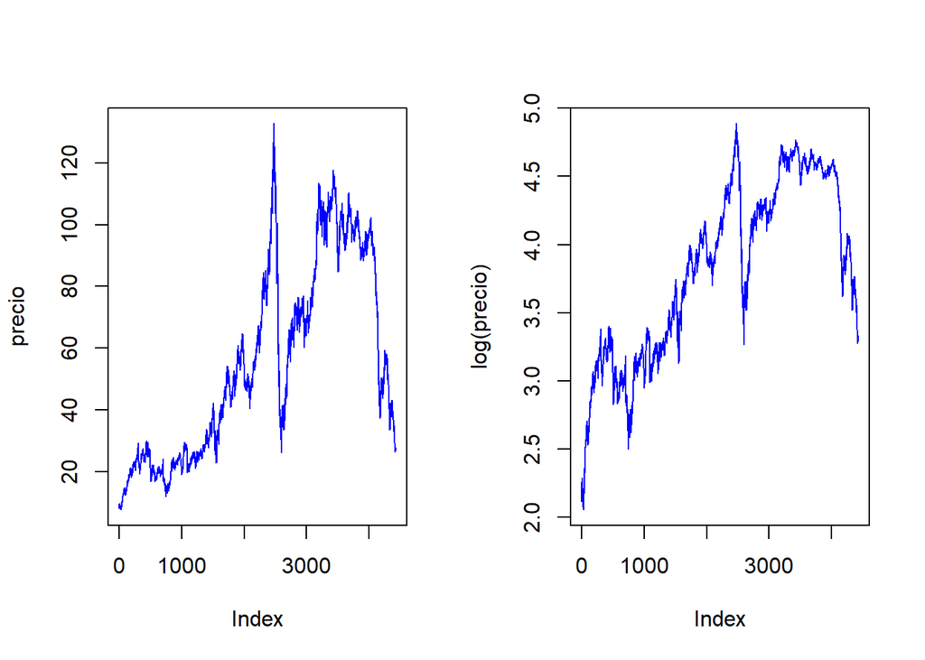

```r
par(mfrow=c(1,2))
plot(precio,col="blue",type="l")

# realizamos una transformación en los datos pues los datos originales
# tienen tendencia y variabilidad creciente
plot(log(precio),col="blue",type="l")
```

Después, vemos los cambios en los precios de un día a otro (en logarítmo), mejor conocidos como *logrendimientos*:

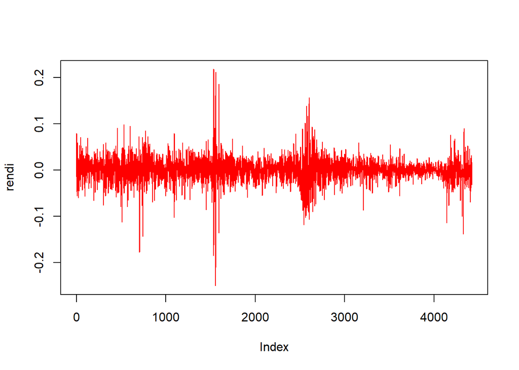

```r
# lo que mas interesa es modelar los rendimientos
# rendi = log(precio[t]) - log(precio[t-1])

rendi <- diff(log(precio))

# graficamos
plot(rendi, col="red",type="l")
```

siento este un patrón muy usual de los GARCH. También podemos identificar estos modelos por medio de las gráficas ACF y PACF

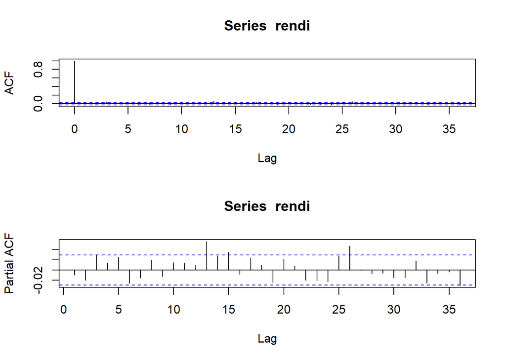

```r
par(mfrow=c(2,1))

acf(rendi)
pacf(rendi)
```

parecen estar No correlacionados o un ruido blanco, porque los valores del acf y pacf quedan dentro de las bandas de confianza pero de acuerdo a los datos SI existe relacion de dependencia.

Vemos también las gráficas ACF y PACF de los rendimientos al cuadrado y en valor absuluto:

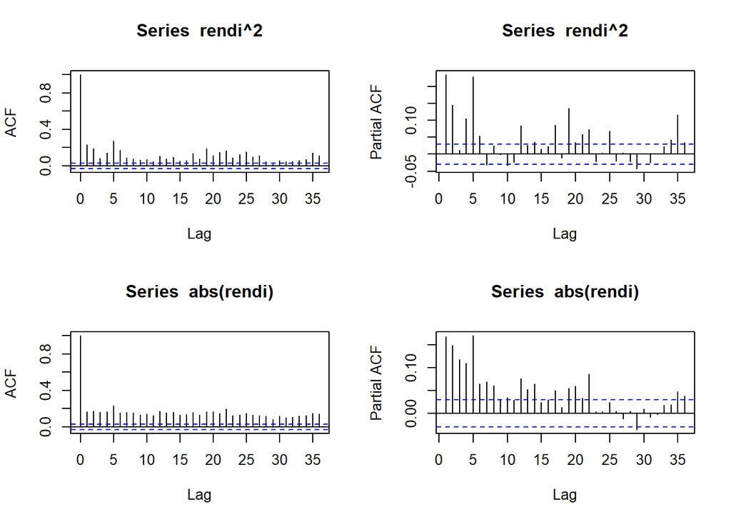

```r
par(mfrow=c(2,2))

# Rendimientos al cuadrado
acf(rendi^2)
pacf(rendi^2)

# Rendimientos en valor absoluto
acf(abs(rendi))
pacf(abs(rendi))
```

donde aquí se resaltan varios valores que no quedan dentro de las bandas, así, podemos rechazar la idea de que estamos trabajando con un ruido blanco.

Nos podemos auxiliar de pruebas no paramétricas

```r
Box.test(rendi,1)
```

```
##
##  Box-Pierce test
##
## data:  rendi
## X-squared = 0.40396, df = 1, p-value = 0.525
```

```r
for(k in 1:5){print(Box.test(rendi,k))}
```

```
##
##  Box-Pierce test
##
## data:  rendi
## X-squared = 0.40396, df = 1, p-value = 0.525
##
##
##  Box-Pierce test
##
## data:  rendi
## X-squared = 2.1285, df = 2, p-value = 0.345
##
##
##  Box-Pierce test
##
## data:  rendi
## X-squared = 5.9072, df = 3, p-value = 0.1162
##
##
##  Box-Pierce test
##
## data:  rendi
## X-squared = 6.7422, df = 4, p-value = 0.1502
##
##
##  Box-Pierce test
##
## data:  rendi
## X-squared = 9.2203, df = 5, p-value = 0.1006
```

```r
Box.test(rendi^2)
```

```
##
##  Box-Pierce test
##
## data:  rendi^2
## X-squared = 243.49, df = 1, p-value < 2.2e-16
```

```r
Box.test(abs(rendi))
```

```
##
##  Box-Pierce test
##
## data:  abs(rendi)
## X-squared = 123.9, df = 1, p-value < 2.2e-16
```

donde vemos que se rechaza $H_{0}$ para el caso de la prueba *Box-Pierce* para los rendimientos al cuadrado y los absolutos de los rendimientos, es decir, para estos caso, estamos rechazando la “independencia” de los datos.

#### Estimación

Procedemos ahora a la estimación GARCH adecuada para nuestros datos

```r
 # probamos con un primer modelo:

mod11 <- garchFit(formula = ~garch(1,1), data= rendi)
```

[output not shown]

[output cut: 43 more lines]

[output not shown]

```r
summary(mod11)
```

```
##
## Title:
##  GARCH Modelling
##
## Call:
##  garchFit(formula = ~garch(1, 1), data = rendi)
##
## Mean and Variance Equation:
##  data ~ garch(1, 1)
## <environment: 0x00000000223c65d0>
##  [data = rendi]
##
## Conditional Distribution:
##  norm
##
## Coefficient(s):
##         mu       omega      alpha1       beta1
## 4.5737e-04  1.5492e-06  4.9328e-02  9.5001e-01
##
## Std. Errors:
##  based on Hessian
##
## Error Analysis:
##         Estimate  Std. Error  t value Pr(>|t|)
## mu     4.574e-04   2.641e-04    1.732  0.08333 .
## omega  1.549e-06   4.508e-07    3.436  0.00059 ***
## alpha1 4.933e-02   4.489e-03   10.988  < 2e-16 ***
## beta1  9.500e-01   4.190e-03  226.709  < 2e-16 ***
## ---
## Signif. codes:  0 '***' 0.001 '**' 0.01 '*' 0.05 '.' 0.1 ' ' 1
##
## Log Likelihood:
##  10910.32    normalized:  2.466724
##
## Description:
##  Mon Apr 04 17:05:06 2022 by user: weeee
##
##
## Standardised Residuals Tests:
##                                 Statistic p-Value
##  Jarque-Bera Test   R    Chi^2  2496.071  0
##  Shapiro-Wilk Test  R    W      0.9694204 0
##  Ljung-Box Test     R    Q(10)  22.82427  0.01141414
##  Ljung-Box Test     R    Q(15)  30.06962  0.01167292
##  Ljung-Box Test     R    Q(20)  33.92049  0.0266676
##  Ljung-Box Test     R^2  Q(10)  6.256216  0.7932973
##  Ljung-Box Test     R^2  Q(15)  17.7053   0.2784756
##  Ljung-Box Test     R^2  Q(20)  24.40991  0.224945
##  LM Arch Test       R    TR^2   15.78802  0.2011392
##
## Information Criterion Statistics:
##       AIC       BIC       SIC      HQIC
## -4.931640 -4.925857 -4.931641 -4.929600
```

donde los parámetros de `garch()` suelen ser el 1 y el 2. De tal manera

```r
# Probamos
mod11 <- garchFit(formula = ~garch(1,1), data= rendi)
mod12 <- garchFit(formula = ~garch(1,2), data= rendi)
mod21 <- garchFit(formula = ~garch(2,1), data= rendi)
mod22 <- garchFit(formula = ~garch(2,2), data= rendi)

# Usando metodos de bondad de ajuste, analisis de residuales, significancia de los parametros, elegimos el mejor modelo

summary(mod11)
summary(mod12)
summary(mod21)
summary(mod22)
```

y hacemos el análisis con cada modelo:

```r
# Haremos el análisis sólo para el modelo mod11

mod <- mod11
summary(mod)
```

```
##
## Title:
##  GARCH Modelling
##
## Call:
##  garchFit(formula = ~garch(1, 1), data = rendi)
##
## Mean and Variance Equation:
##  data ~ garch(1, 1)
## <environment: 0x00000000223c65d0>
##  [data = rendi]
##
## Conditional Distribution:
##  norm
##
## Coefficient(s):
##         mu       omega      alpha1       beta1
## 4.5737e-04  1.5492e-06  4.9328e-02  9.5001e-01
##
## Std. Errors:
##  based on Hessian
##
## Error Analysis:
##         Estimate  Std. Error  t value Pr(>|t|)
## mu     4.574e-04   2.641e-04    1.732  0.08333 .
## omega  1.549e-06   4.508e-07    3.436  0.00059 ***
## alpha1 4.933e-02   4.489e-03   10.988  < 2e-16 ***
## beta1  9.500e-01   4.190e-03  226.709  < 2e-16 ***
## ---
## Signif. codes:  0 '***' 0.001 '**' 0.01 '*' 0.05 '.' 0.1 ' ' 1
##
## Log Likelihood:
##  10910.32    normalized:  2.466724
##
## Description:
##  Mon Apr 04 17:05:06 2022 by user: weeee
##
##
## Standardised Residuals Tests:
##                                 Statistic p-Value
##  Jarque-Bera Test   R    Chi^2  2496.071  0
##  Shapiro-Wilk Test  R    W      0.9694204 0
##  Ljung-Box Test     R    Q(10)  22.82427  0.01141414
##  Ljung-Box Test     R    Q(15)  30.06962  0.01167292
##  Ljung-Box Test     R    Q(20)  33.92049  0.0266676
##  Ljung-Box Test     R^2  Q(10)  6.256216  0.7932973
##  Ljung-Box Test     R^2  Q(15)  17.7053   0.2784756
##  Ljung-Box Test     R^2  Q(20)  24.40991  0.224945
##  LM Arch Test       R    TR^2   15.78802  0.2011392
##
## Information Criterion Statistics:
##       AIC       BIC       SIC      HQIC
## -4.931640 -4.925857 -4.931641 -4.929600
```

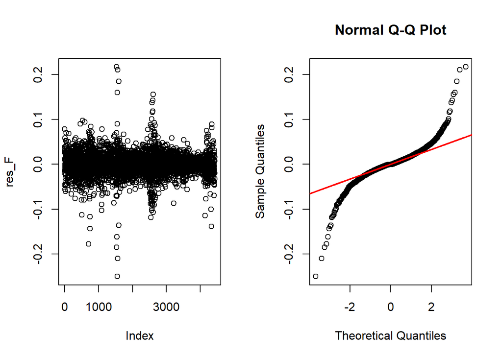

```r
# Comprobamos si es ruido blanco gaussiano
par(mfrow=c(1,2))
res_F <- residuals(mod, standardize=F)
plot(res_F)
qqnorm(res_F)
qqline(res_F,col="red",lwd=2)
```

```r
ad.test(res_F)
```

```
##
##  Anderson-Darling normality test
##
## data:  res_F
## A = 77.529, p-value < 2.2e-16
```

vemos que los valores extremos de la Q-Q están alejados de la recta roja. Además, de la prueba de *Anderson-Darling* rechazamos $H_0$, es decir, se rechaza que los residuos tienen una distribución normal. Así, probamos otras distribuciones de los errores, por ejemplo:

```r
# En los modelos GARCH es usual buscar otro tipo de distribucion para los errores, ya que pueden ser No simetricos, o con colas más pesadas

# Normal sesgada
mod <- garchFit(formula = ~garch(1,1), data=rendi, cond.dist="snorm")

# error generalizado
mod <- garchFit(formula = ~garch(1,1), data=rendi, cond.dist="ged")

# error generalizado sesgada
mod <- garchFit(formula = ~garch(1,1), data=rendi, cond.dist="sged")

# t-student
mod <- garchFit(formula = ~garch(1,1), data=rendi, cond.dist="std")

# t-student sesgada
mod <- garchFit(formula = ~garch(1,1), data=rendi, cond.dist="sstd")
```

Finalmente realizamos la predicción:

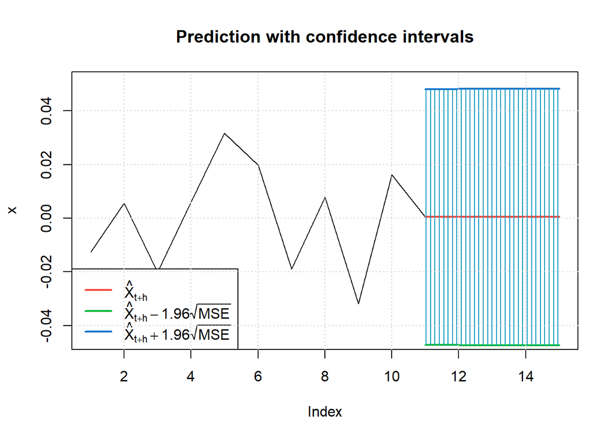

```
##   meanForecast  meanError standardDeviation lowerInterval upperInterval
## 1 0.0004573678 0.02432582        0.02432582   -0.04722036    0.04813509
## 2 0.0004573678 0.02434955        0.02434955   -0.04726687    0.04818161
## 3 0.0004573678 0.02437324        0.02437324   -0.04731331    0.04822804
## 4 0.0004573678 0.02439690        0.02439690   -0.04735967    0.04827441
## 5 0.0004573678 0.02442051        0.02442051   -0.04740596    0.04832069
```

```r
predict(mod, n.ahead = 5, trace = FALSE, mse = c("cond"),
        plot=TRUE, nx=10, crit_val=NULL, conf=NULL)
```

que notamos también constante.